# VNI Analysis of RDM behavior

Hayley Brooks

##### Subject information

```r
subIDs = unique(mriBehClean$subjectIndex);
nSub = length(subIDs);
nSub
```

```
[1] 48
```

```r
#sprintf("N = %s", nSub)
```

### Big Question

#### Does risk-taking change as a function of temporal context at three levels?

1. Immediate (past outcome)
2. Neighborhood (shifts)
3. Global (earnings relative to expected)

### Trial-level model

##### Summary: Participants more likely to choose an option as its amount increases (no effect of ground expected value)

```r
model1_trialLevel = glmer(choice~ 0 + gainSC + altSC + grndEVscaled + (0+ gainSC + altSC|subjectIndex), data = mriBehClean, family = "binomial"); # model identical to VIC

summary(model1_trialLevel);
```

```
Generalized linear mixed model fit by maximum likelihood (Laplace Approximation) ['glmerMod']
 Family: binomial  ( logit )
Formula: choice ~ 0 + gainSC + altSC + grndEVscaled + (0 + gainSC + altSC |      subjectIndex)
   Data: mriBehClean

     AIC      BIC   logLik deviance df.resid
  8058.9   8102.4  -4023.4   8046.9    10422

Scaled residuals:
    Min      1Q  Median      3Q     Max
-35.149  -0.444  -0.061   0.399 112.462

Random effects:
 Groups       Name   Variance Std.Dev. Corr
 subjectIndex gainSC  82.97    9.109
              altSC  326.92   18.081   -0.97
Number of obs: 10428, groups:  subjectIndex, 48

Fixed effects:
             Estimate Std. Error z value Pr(>|z|)
gainSC         16.118      1.925   8.373   <2e-16 ***
altSC         -41.078      3.798 -10.815   <2e-16 ***
grndEVscaled    6.990      5.392   1.296    0.195
---
Signif. codes:  0 ‘***’ 0.001 ‘**’ 0.01 ‘*’ 0.05 ‘.’ 0.1 ‘ ’ 1

Correlation of Fixed Effects:
            gainSC altSC
altSC       -0.026
grndEVscald -0.697 -0.690
```

##### Pull out “predicted” values from trial-level model and save as variable “pred” in mriBehClean dataframe

**Using “offset”, they’ll be applied inside the softmax with a weight of 1 every time, in effect accounting for our best current-trial predictions by directly entering those predictions on a trial-by-trial level. This lets us retain the binomial analysis structure vs using residuals (“resids”), which is much more accurate.**

```r
mriBehClean$pred= predict(model1_trialLevel,type="link");
par(mfrow=c(1,1))
#plot(mriBehClean$pred, ylab="predicted values");
```

#### 1) Immediate timescale: past outcome

##### Past outcome amount and type: past outcome and type alone in models both not significant. In a model with past outcome type, type is significant (beta = .12(.06), p=.03) and interacts with outcome amount (beta = -.54(.2), p=.005). The model with the interaction performs better by AIC comparison.

```r
model2_potc_amt = glmer(choice ~ 0 + poc1scaled + (1|subjectIndex), data=mriBehClean, family="binomial", offset=pred);
summary(model2_potc_amt);  # ns; AIC = 7592.9
```

```
Generalized linear mixed model fit by maximum likelihood (Laplace Approximation) ['glmerMod']
 Family: binomial  ( logit )
Formula: choice ~ 0 + poc1scaled + (1 | subjectIndex)
   Data: mriBehClean
 Offset: pred

     AIC      BIC   logLik deviance df.resid
  7592.9   7607.4  -3794.4   7588.9    10381

Scaled residuals:
    Min      1Q  Median      3Q     Max
-35.185  -0.443  -0.062   0.399 112.431

Random effects:
 Groups       Name        Variance  Std.Dev.
 subjectIndex (Intercept) 0.0009059 0.0301
Number of obs: 10383, groups:  subjectIndex, 48

Fixed effects:
            Estimate Std. Error z value Pr(>|z|)
poc1scaled 0.0004242  0.0835272   0.005    0.996
```

```r
model2_potc_type = glmer(choice ~ 0 + poc1type + (1|subjectIndex), data=mriBehClean, family="binomial", offset=pred);
summary(model2_potc_type); # ns; AIC =7592.1
```

```
Generalized linear mixed model fit by maximum likelihood (Laplace Approximation) ['glmerMod']
 Family: binomial  ( logit )
Formula: choice ~ 0 + poc1type + (1 | subjectIndex)
   Data: mriBehClean
 Offset: pred

     AIC      BIC   logLik deviance df.resid
  7592.1   7606.5  -3794.0   7588.1    10381

Scaled residuals:
    Min      1Q  Median      3Q     Max
-35.856  -0.443  -0.062   0.399 110.323

Random effects:
 Groups       Name        Variance  Std.Dev.
 subjectIndex (Intercept) 0.0009635 0.03104
Number of obs: 10383, groups:  subjectIndex, 48

Fixed effects:
         Estimate Std. Error z value Pr(>|z|)
poc1type  0.03812    0.04217   0.904    0.366
```

```r
model2_potc_amt_type_intxn = glmer(choice ~ 0 + poc1type*poc1scaled + (1|subjectIndex), data=mriBehClean, family="binomial", offset=pred);
summary(model2_potc_amt_type_intxn); # negative interaction between outcome type and amount; AIC = 7588.0
```

```
Generalized linear mixed model fit by maximum likelihood (Laplace Approximation) ['glmerMod']
 Family: binomial  ( logit )
Formula: choice ~ 0 + poc1type * poc1scaled + (1 | subjectIndex)
   Data: mriBehClean
 Offset: pred

     AIC      BIC   logLik deviance df.resid
  7588.0   7616.9  -3790.0   7580.0    10379

Scaled residuals:
    Min      1Q  Median      3Q     Max
-32.490  -0.441  -0.062   0.401 114.810

Random effects:
 Groups       Name        Variance Std.Dev.
 subjectIndex (Intercept) 0.003258 0.05708
Number of obs: 10383, groups:  subjectIndex, 48

Fixed effects:
                    Estimate Std. Error z value Pr(>|z|)
poc1type             0.12294    0.05584   2.202  0.02768 *
poc1scaled           0.22060    0.14009   1.575  0.11532
poc1type:poc1scaled -0.53976    0.19380  -2.785  0.00535 **
---
Signif. codes:  0 ‘***’ 0.001 ‘**’ 0.01 ‘*’ 0.05 ‘.’ 0.1 ‘ ’ 1

Correlation of Fixed Effects:
            pc1typ pc1scl
poc1scaled  -0.016
pc1typ:pc1s -0.453 -0.704
```

#### 2) Neighborhood timescale: Shifts

##### Summary: Risk-taking increases following a positive shift only and the effect is short-lasting (similar to VIC). Shift does not interact with run size or past outcome.

```r
model3_signed_shifts = glmer(choice~0 + shiftDiffsc + (1|subjectIndex), data=mriBehClean, family="binomial", offset=pred);
```

```
boundary (singular) fit: see help('isSingular')
```

```r
summary(model3_signed_shifts); # signed shift difference, significant
```

```
Generalized linear mixed model fit by maximum likelihood (Laplace Approximation) ['glmerMod']
 Family: binomial  ( logit )
Formula: choice ~ 0 + shiftDiffsc + (1 | subjectIndex)
   Data: mriBehClean
 Offset: pred

     AIC      BIC   logLik deviance df.resid
  7660.6   7675.1  -3828.3   7656.6    10426

Scaled residuals:
    Min      1Q  Median      3Q     Max
-35.149  -0.445  -0.062   0.400 112.462

Random effects:
 Groups       Name        Variance Std.Dev.
 subjectIndex (Intercept) 4e-14    2e-07
Number of obs: 10428, groups:  subjectIndex, 48

Fixed effects:
            Estimate Std. Error z value Pr(>|z|)
shiftDiffsc   1.0648     0.5026   2.119   0.0341 *
---
Signif. codes:  0 ‘***’ 0.001 ‘**’ 0.01 ‘*’ 0.05 ‘.’ 0.1 ‘ ’ 1
optimizer (Nelder_Mead) convergence code: 0 (OK)
boundary (singular) fit: see help('isSingular')
```

```r
model3_abs_shift = glmer(choice ~ 0 + shiftDiffscABs + (1|subjectIndex), data=mriBehClean, family="binomial", offset=pred);
summary(model3_abs_shift); # absolute shift difference, ns
```

```
Generalized linear mixed model fit by maximum likelihood (Laplace Approximation) ['glmerMod']
 Family: binomial  ( logit )
Formula: choice ~ 0 + shiftDiffscABs + (1 | subjectIndex)
   Data: mriBehClean
 Offset: pred

     AIC      BIC   logLik deviance df.resid
  7663.1   7677.6  -3829.5   7659.1    10426

Scaled residuals:
    Min      1Q  Median      3Q     Max
-35.166  -0.448  -0.062   0.398 112.457

Random effects:
 Groups       Name        Variance  Std.Dev.
 subjectIndex (Intercept) 0.0003619 0.01902
Number of obs: 10428, groups:  subjectIndex, 48

Fixed effects:
               Estimate Std. Error z value Pr(>|z|)
shiftDiffscABs   0.7170     0.5025   1.427    0.154
```

```r
model3_pos_neg_shifts = glmer(choice ~ 0 + shiftDiffscPOS + shiftDiffscNEG + (1|subjectIndex), data=mriBehClean, family="binomial", offset=pred);
summary(model3_pos_neg_shifts); # both positive and negative shift difference, only positive significant
```

```
Generalized linear mixed model fit by maximum likelihood (Laplace Approximation) ['glmerMod']
 Family: binomial  ( logit )
Formula: choice ~ 0 + shiftDiffscPOS + shiftDiffscNEG + (1 | subjectIndex)
   Data: mriBehClean
 Offset: pred

     AIC      BIC   logLik deviance df.resid
  7660.1   7681.9  -3827.0   7654.1    10425

Scaled residuals:
    Min      1Q  Median      3Q     Max
-35.168  -0.447  -0.062   0.399 112.458

Random effects:
 Groups       Name        Variance  Std.Dev.
 subjectIndex (Intercept) 0.0004146 0.02036
Number of obs: 10428, groups:  subjectIndex, 48

Fixed effects:
               Estimate Std. Error z value Pr(>|z|)
shiftDiffscPOS   1.9151     0.7324   2.615  0.00892 **
shiftDiffscNEG   0.3182     0.6854   0.464  0.64244
---
Signif. codes:  0 ‘***’ 0.001 ‘**’ 0.01 ‘*’ 0.05 ‘.’ 0.1 ‘ ’ 1

Correlation of Fixed Effects:
            shDPOS
shftDffsNEG -0.004
```

```r
m3_coef_posShift = fixef(model3_pos_neg_shifts)[1];

## Plot the effect of positive shift
# scaled shift amounts = 0 to .33 (or 0 to 20 nonscaled)
PgamPosShiftZero = 1/(1+exp(-1*( (m3_coef_posShift*0) ))); # should be .5
PgamPosShiftLarge = 1/(1+exp(-1*( (m3_coef_posShift*.33) )));
# probability of gambling following large positive shift = 0.6518448, a %15.2 increase
PgamPosShiftMedium = 1/(1+exp(-1*( (m3_coef_posShift*.16) )));
# probability of gambling following medium positive shift = 0.5754388, a %7.5 increase


plot(c(PgamPosShiftZero, PgamPosShiftMedium,PgamPosShiftLarge), type="l", lwd=3, col="blue", axes=F, ylab="p(gamble)", xlab="positive shift", main="risk taking as a function of positive shift")
axis(1, labels=c("no shift", "medium", "large"), at=c(1,2,3))
```

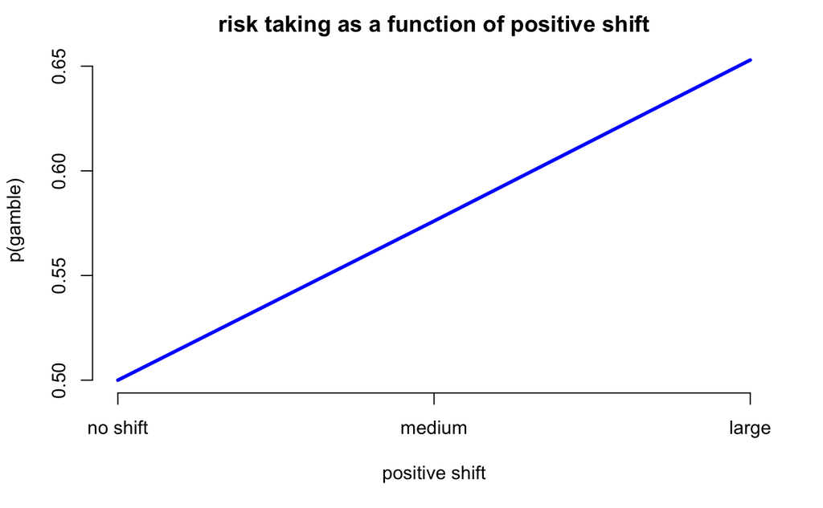

```r
axis(2)
```

```r
NA
NA
NA
```

#### How far back does shift effect go?

```r
# create new positive shift variable (n-1)
newMat = matrix(data=NA,nrow=nrow(mriBehClean), ncol=2);
newMat[,1] <- mriBehClean$shiftDiffscPOS; #take data from columns
newMat[2:nrow(newMat),1] <- newMat[1:(nrow(newMat)-1),1]; # removes first row, shifts everything up
newMat[1,1] <- NaN #put Nan in for first row (first trial for subject 1, bc there is no past trial)
newMat[,2]<-c(0,diff(mriBehClean$subjectIndex)); #put differences between subjectIndex into newvector, 1s show up when subject changes
newMat[newMat[,2]==1,]=NaN; #in newmtx, when diff = 1, replace with NaN, this replaces first trial with nan
mriBehClean$shiftDiffscPOS1 = newMat[,1];# add new vector to mriBehClean

# do the regressions
model3_pos_shift_howfarback = glmer(choice ~ 0 + shiftDiffscPOS + shiftDiffscPOS1 + (1|subjectIndex), data=mriBehClean, family="binomial", offset=pred);
summary(model3_pos_shift_howfarback); #short lasting, only trial directly after a shift
```

```
Generalized linear mixed model fit by maximum likelihood (Laplace Approximation) ['glmerMod']
 Family: binomial  ( logit )
Formula: choice ~ 0 + shiftDiffscPOS + shiftDiffscPOS1 + (1 | subjectIndex)
   Data: mriBehClean
 Offset: pred

     AIC      BIC   logLik deviance df.resid
  7587.5   7609.3  -3790.8   7581.5    10380

Scaled residuals:
    Min      1Q  Median      3Q     Max
-35.206  -0.448  -0.063   0.398 112.457

Random effects:
 Groups       Name        Variance Std.Dev.
 subjectIndex (Intercept) 0.002147 0.04634
Number of obs: 10383, groups:  subjectIndex, 48

Fixed effects:
                Estimate Std. Error z value Pr(>|z|)
shiftDiffscPOS    1.9148     0.7324   2.615  0.00893 **
shiftDiffscPOS1   0.5863     0.7545   0.777  0.43718
---
Signif. codes:  0 ‘***’ 0.001 ‘**’ 0.01 ‘*’ 0.05 ‘.’ 0.1 ‘ ’ 1

Correlation of Fixed Effects:
            shDPOS
shftDffPOS1 0.007
```

#### Does positive shift interact with previous run size or past outcome?

```r
# positive shift amount and run size before positive shift
model3_shift_pos_runSize = glmer(choice ~ 0 + shiftDiffscPOS*runSizePOS +(1|subjectIndex), data=mriBehClean, family="binomial", offset=pred);
summary(model3_shift_pos_runSize); # all betas ns
```

```
Generalized linear mixed model fit by maximum likelihood (Laplace Approximation) ['glmerMod']
 Family: binomial  ( logit )
Formula: choice ~ 0 + shiftDiffscPOS * runSizePOS + (1 | subjectIndex)
   Data: mriBehClean
 Offset: pred

     AIC      BIC   logLik deviance df.resid
  7661.5   7690.5  -3826.8   7653.5    10424

Scaled residuals:
    Min      1Q  Median      3Q     Max
-35.184  -0.449  -0.062   0.398 112.456

Random effects:
 Groups       Name        Variance  Std.Dev.
 subjectIndex (Intercept) 0.0007795 0.02792
Number of obs: 10428, groups:  subjectIndex, 48

Fixed effects:
                          Estimate Std. Error z value Pr(>|z|)
shiftDiffscPOS             1.22984    2.54786   0.483    0.629
runSizePOS                 0.02327    0.02712   0.858    0.391
shiftDiffscPOS:runSizePOS -0.04974    0.24558  -0.203    0.840

Correlation of Fixed Effects:
            shDPOS rnSPOS
runSizePOS  -0.087
shDPOS:SPOS -0.813 -0.450
```

```r
# both positive and negative shift and run size before positive and negative shift
model3_shift_pos_neg_runSize = glmer(choice ~ 0 + shiftDiffscPOS*runSizePOS + shiftDiffscNEG*runSizeNEG + (1|subjectIndex), data=mriBehClean, family="binomial", offset=pred);
summary(model3_shift_pos_neg_runSize); #all betas ns
```

```
Generalized linear mixed model fit by maximum likelihood (Laplace Approximation) ['glmerMod']
 Family: binomial  ( logit )
Formula: choice ~ 0 + shiftDiffscPOS * runSizePOS + shiftDiffscNEG * runSizeNEG +      (1 | subjectIndex)
   Data: mriBehClean
 Offset: pred

     AIC      BIC   logLik deviance df.resid
  7663.9   7714.7  -3825.0   7649.9    10421

Scaled residuals:
    Min      1Q  Median      3Q     Max
-35.186  -0.449  -0.063   0.397 112.457

Random effects:
 Groups       Name        Variance  Std.Dev.
 subjectIndex (Intercept) 0.0008197 0.02863
Number of obs: 10428, groups:  subjectIndex, 48

Fixed effects:
                          Estimate Std. Error z value Pr(>|z|)
shiftDiffscPOS             1.23035    2.48415   0.495    0.620
runSizePOS                 0.02328    0.02711   0.859    0.391
shiftDiffscNEG             2.95572    2.30952   1.280    0.201
runSizeNEG                 0.03491    0.02651   1.317    0.188
shiftDiffscPOS:runSizePOS -0.04978    0.24151  -0.206    0.837
shiftDiffscNEG:runSizeNEG -0.08936    0.25481  -0.351    0.726

Correlation of Fixed Effects:
            shDPOS rnSPOS shDNEG rnSNEG sDPOS:
runSizePOS  -0.085
shftDffsNEG  0.004 -0.001
runSizeNEG   0.000  0.002 -0.054
shDPOS:SPOS -0.806 -0.461 -0.003  0.000
shDNEG:SNEG -0.003  0.001 -0.828  0.546  0.003
```

```r
# Does positive shift interact with past outcome?
model3_posShift_potc_intxn = glmer(choice ~ 0 + shiftDiffscPOS*poc1scaled + (1|subjectIndex), data=mriBehClean, family="binomial", offset=pred);
summary(model3_posShift_potc_intxn); #all betas ns
```

```
Generalized linear mixed model fit by maximum likelihood (Laplace Approximation) ['glmerMod']
 Family: binomial  ( logit )
Formula: choice ~ 0 + shiftDiffscPOS * poc1scaled + (1 | subjectIndex)
   Data: mriBehClean
 Offset: pred

     AIC      BIC   logLik deviance df.resid
  7589.2   7618.2  -3790.6   7581.2    10379

Scaled residuals:
    Min      1Q  Median      3Q     Max
-34.795  -0.445  -0.062   0.399 113.189

Random effects:
 Groups       Name        Variance Std.Dev.
 subjectIndex (Intercept) 0.001434 0.03787
Number of obs: 10383, groups:  subjectIndex, 48

Fixed effects:
                          Estimate Std. Error z value Pr(>|z|)
shiftDiffscPOS             1.15538    1.12224   1.030    0.303
poc1scaled                -0.02527    0.08518  -0.297    0.767
shiftDiffscPOS:poc1scaled  5.30091    5.81848   0.911    0.362

Correlation of Fixed Effects:
            shDPOS pc1scl
poc1scaled   0.037
shftDfPOS:1 -0.756 -0.115
```

#### 3) Global timescale: Earnings

```r
# First looking at earnings and trial in a model (no past outcome, shift variable)
model4_earnings_trial = glmer(choice~0 + earningsSC + trialSC + (1|subjectIndex), data=mriBehClean, family="binomial", offset=pred);
summary(model4_earnings_trial); # both significant, betas similar size but opposite valence, AIC = 7649.2
```

```
Generalized linear mixed model fit by maximum likelihood (Laplace Approximation) ['glmerMod']
 Family: binomial  ( logit )
Formula: choice ~ 0 + earningsSC + trialSC + (1 | subjectIndex)
   Data: mriBehClean
 Offset: pred

     AIC      BIC   logLik deviance df.resid
  7649.2   7670.9  -3821.6   7643.2    10425

Scaled residuals:
    Min      1Q  Median      3Q     Max
-35.852  -0.447  -0.063   0.390 105.838

Random effects:
 Groups       Name        Variance Std.Dev.
 subjectIndex (Intercept) 0.003169 0.05629
Number of obs: 10428, groups:  subjectIndex, 48

Fixed effects:
           Estimate Std. Error z value Pr(>|z|)
earningsSC   2.9154     0.7383   3.949 7.85e-05 ***
trialSC     -2.4610     0.6347  -3.878 0.000105 ***
---
Signif. codes:  0 ‘***’ 0.001 ‘**’ 0.01 ‘*’ 0.05 ‘.’ 0.1 ‘ ’ 1

Correlation of Fixed Effects:
        ernnSC
trialSC -0.997
```

```r
model4_earningsNorm_trial = glmer(choice~0 + earningsNormalized + trialSC + (1|subjectIndex), data=mriBehClean, family="binomial", offset=pred);
summary(model4_earningsNorm_trial); # both significant, betas similar size but opposite valence, AIC = 7657.1
```

```
Generalized linear mixed model fit by maximum likelihood (Laplace Approximation) ['glmerMod']
 Family: binomial  ( logit )
Formula: choice ~ 0 + earningsNormalized + trialSC + (1 | subjectIndex)
   Data: mriBehClean
 Offset: pred

     AIC      BIC   logLik deviance df.resid
  7657.1   7678.9  -3825.6   7651.1    10425

Scaled residuals:
    Min      1Q  Median      3Q     Max
-35.826  -0.446  -0.062   0.392 108.218

Random effects:
 Groups       Name        Variance Std.Dev.
 subjectIndex (Intercept) 0.003929 0.06268
Number of obs: 10428, groups:  subjectIndex, 48

Fixed effects:
                   Estimate Std. Error z value Pr(>|z|)
earningsNormalized   2.3615     0.8053   2.932  0.00336 **
trialSC             -2.2802     0.7945  -2.870  0.00411 **
---
Signif. codes:  0 ‘***’ 0.001 ‘**’ 0.01 ‘*’ 0.05 ‘.’ 0.1 ‘ ’ 1

Correlation of Fixed Effects:
        ernngN
trialSC -0.998
```

```r
# model earning scaled fits better than earnings normalized - allowing individuals to vary does a little better than them all ending at the same place (i.e. at 1)



# pull and store coefficients
m4_coef_trial_Earn = fixef(model4_earnings_trial);
earnCoef = m4_coef_trial_Earn[1];
triCoef = m4_coef_trial_Earn[2];

# plot a couple of subs' earnings and pgamble over the task as a function of earnings and trial
sub1 = mriBehClean[mriBehClean$subjectIndex==7,];
PgamSub1EarnTrial =1/(1+exp(-1*( (triCoef*sub1$trialSC) + (earnCoef*sub1$earningsSC) )));

sub2 = mriBehClean[mriBehClean$subjectIndex==35,];
PgamSub2EarnTrial =1/(1+exp(-1*( (triCoef*sub2$trialSC) + (earnCoef*sub2$earningsSC) )))

sub3 = mriBehClean[mriBehClean$subjectIndex==52,];
PgamSub3EarnTrial =1/(1+exp(-1*( (triCoef*sub3$trialSC) + (earnCoef*sub3$earningsSC) )))

sub4 = mriBehClean[mriBehClean$subjectIndex==15,];
PgamSub4EarnTrial =1/(1+exp(-1*( (triCoef*sub4$trialSC) + (earnCoef*sub4$earningsSC) )))

sub5 = mriBehClean[mriBehClean$subjectIndex==28,];
PgamSub5EarnTrial =1/(1+exp(-1*( (triCoef*sub5$trialSC) + (earnCoef*sub5$earningsSC) )))

#pdf("/Users/hayley/Desktop/shenhavLabTalk/vniEarningsExpectations.pdf")
plot(PgamSub1EarnTrial, type="l", col="darkgreen", lwd=3, ylim=c(.4,.6), ylab="p(gamble)", xlab="trial", main="risk taking as a function\n of trial and earnings", axes = F)
abline(a=.5, b=0, lty="dashed", col="darkgrey", lwd=2)
```

```r
axis(1, at=c(1,110,219), lwd=5)
axis(2, lwd=5)
```

```r
lines(PgamSub2EarnTrial, col="darkred", lwd=3);
lines(PgamSub3EarnTrial, col="darkblue", lwd=3);
```

```r
lines(PgamSub4EarnTrial, col="darkorange", lwd=3);
lines(PgamSub5EarnTrial, col="goldenrod", lwd=3);
```

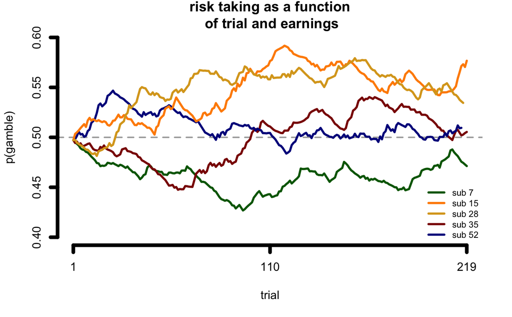

```r
legend("bottomright", legend=c("sub 7","sub 15", "sub 28" ,"sub 35", "sub 52"), lty = 1, lwd=3, bty="n", col=c("darkgreen", "darkorange", "goldenrod", "darkred","darkblue"), cex=.75)
```

```r
#dev.off()

plot(sub1$earningsSC,type="l", col="darkgreen", lwd=3, xlab="trial", ylab="earnings (normalized)", main="earnings across the task", ylim=c(0,1))
lines(sub2$earningsSC, col="darkred", lwd=3)
```

```r
lines(sub3$earningsSC, col="darkblue", lwd=3)
lines(sub4$earningsSC, col="darkorange", lwd=3)
```

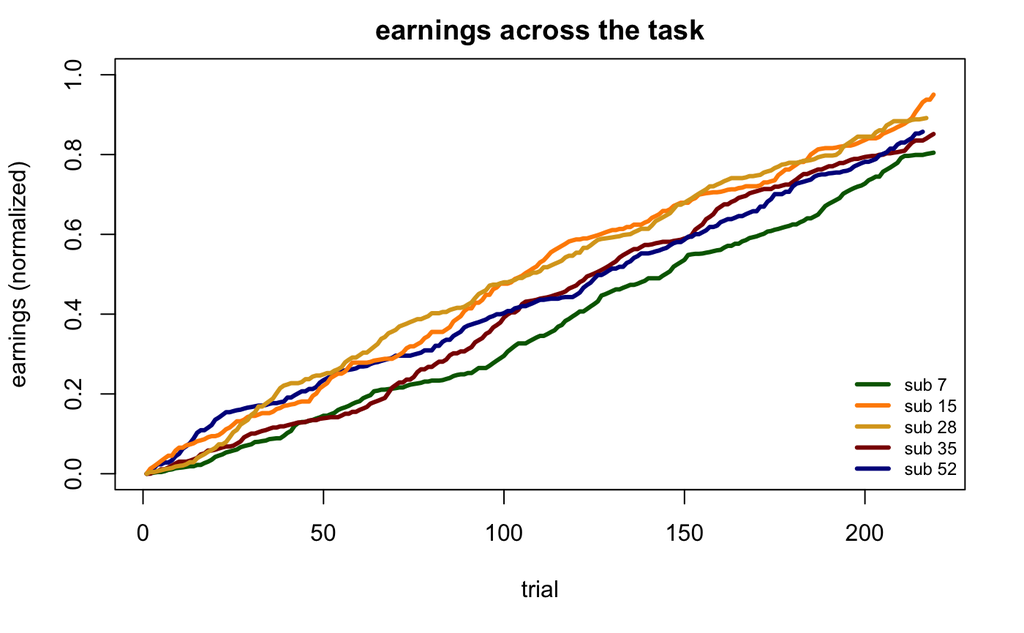

```r
lines(sub5$earningsSC, col="goldenrod", lwd=3)

legend("bottomright", legend=c("sub 7","sub 15", "sub 28" ,"sub 35", "sub 52"), lty = 1, lwd=3, bty="n", col=c("darkgreen", "darkorange", "goldenrod", "darkred","darkblue"), cex=.75)
```

```r
# Plot #1 basically shows the difference between earnings and trial
```

```r
# Model and plot with interaction term between earnings and trial
    # Interaction was trending here, so I am not sure how much to focus on this. The above model and plots seem more informative.
model4_earnings_trial_intxn = glmer(choice~0 + earningsSC*trialSC + (1|subjectIndex), data=mriBehClean, family="binomial", offset=pred);
summary(model4_earnings_trial_intxn); # interaction significant, effects of trial and earnings similar as previous models except that earnings beta is slightly smaller now AIC = 7647.1
```

```
Generalized linear mixed model fit by maximum likelihood (Laplace Approximation) ['glmerMod']
 Family: binomial  ( logit )
Formula: choice ~ 0 + earningsSC * trialSC + (1 | subjectIndex)
   Data: mriBehClean
 Offset: pred

     AIC      BIC   logLik deviance df.resid
  7647.1   7676.1  -3819.6   7639.1    10424

Scaled residuals:
    Min      1Q  Median      3Q     Max
-35.569  -0.440  -0.062   0.391 108.262

Random effects:
 Groups       Name        Variance Std.Dev.
 subjectIndex (Intercept) 0.001367 0.03697
Number of obs: 10428, groups:  subjectIndex, 48

Fixed effects:
                   Estimate Std. Error z value Pr(>|z|)
earningsSC           2.4177     0.7645   3.163 0.001563 **
trialSC             -2.4196     0.6264  -3.863 0.000112 ***
earningsSC:trialSC   0.5921     0.2931   2.020 0.043367 *
---
Signif. codes:  0 ‘***’ 0.001 ‘**’ 0.01 ‘*’ 0.05 ‘.’ 0.1 ‘ ’ 1

Correlation of Fixed Effects:
            ernnSC trilSC
trialSC     -0.954
ernngsSC:SC -0.312  0.023
```

```r
model4_earningsNorm_trial_intxn = glmer(choice~0 + earningsNormalized*trialSC + (1|subjectIndex), data=mriBehClean, family="binomial", offset=pred);
summary(model4_earningsNorm_trial_intxn); # no interaction but earnings and trial significant as above AIC = 7655.5
```

```
Generalized linear mixed model fit by maximum likelihood (Laplace Approximation) ['glmerMod']
 Family: binomial  ( logit )
Formula: choice ~ 0 + earningsNormalized * trialSC + (1 | subjectIndex)
   Data: mriBehClean
 Offset: pred

     AIC      BIC   logLik deviance df.resid
  7655.5   7684.5  -3823.8   7647.5    10424

Scaled residuals:
    Min      1Q  Median      3Q     Max
-35.548  -0.441  -0.062   0.393 110.485

Random effects:
 Groups       Name        Variance Std.Dev.
 subjectIndex (Intercept) 0.002191 0.04681
Number of obs: 10428, groups:  subjectIndex, 48

Fixed effects:
                           Estimate Std. Error z value Pr(>|z|)
earningsNormalized           1.9409     0.8244   2.354  0.01856 *
trialSC                     -2.2318     0.7873  -2.835  0.00459 **
earningsNormalized:trialSC   0.4881     0.2560   1.906  0.05663 .
---
Signif. codes:  0 ‘***’ 0.001 ‘**’ 0.01 ‘*’ 0.05 ‘.’ 0.1 ‘ ’ 1

Correlation of Fixed Effects:
            ernngN trilSC
trialSC     -0.970
ernngsNr:SC -0.259  0.025
```

Plot cumulative earnings for all participants across the task

```r
plot(mriBehClean$earnings[mriBehClean$subjectIndex==1], type = "l",lwd = 2, ylim = c(0,max(mriBehClean$earnings)), xlim= c(0,219), main = "Earnings across task\n each line is a participant", ylab = "earnings", xlab="trial number", axes=FALSE)
axis(1, label = c(1, 219), at = c(1,219), tck = 0, lwd = 3)
```

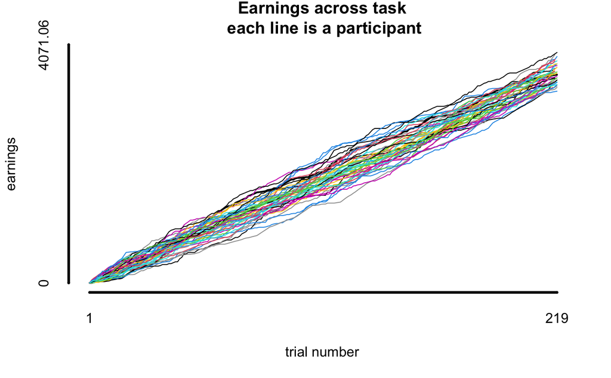

```r
axis(2, label = c(0, max(mriBehClean$earnings)), at = c(0,max(mriBehClean$earnings)), tck = 0, lwd =3)
for(s in 2:nSub){
  points(mriBehClean$earnings[mriBehClean$subjectIndex==s], type="l", lwd = 1, col = mriBehClean$subjectIndex/.2+s)
};
```